# Lab week 2 - Unsupervised methods

Data Science 2: Machine Learning Concepts - CEU 2021

Janos K. Divenyi, Jeno Pal

2021-02-15

```r
library(tidyverse)
library(caret)
library(skimr)
library(janitor)

library(factoextra) # provides nice functions for visualizing the output of PCA
library(NbClust) # for choosing the optimal number of clusters

library(knitr)
library(kableExtra)

theme_set(theme_minimal())
```

Main reference for these topics: [Introduction to Statistical Learning](http://www-bcf.usc.edu/~gareth/ISL/), Chapters 6 and 10. Excellent, simple explanations on deep issues.

StatQuest videos you might find helpful: - [PCA #1](https://www.youtube.com/watch?v=HMOI_lkzW08&ab_channel=StatQuestwithJoshStarmer) - [PCA #2](https://www.youtube.com/watch?v=FgakZw6K1QQ&ab_channel=StatQuestwithJoshStarmer) - [K-Means clustering](https://www.youtube.com/watch?v=4b5d3muPQmA&ab_channel=StatQuestwithJoshStarmer) - [Hierarchical clustering](https://www.youtube.com/watch?v=7xHsRkOdVwo&ab_channel=StatQuestwithJoshStarmer)

## Principal Component Analysis (PCA)

We transform the coordinates of the original variables to capture as much variation as we can with independent (orthogonal) dimensions. For a very nice illustration and discussion, see [here](https://stats.stackexchange.com/questions/2691/making-sense-of-principal-component-analysis-eigenvectors-eigenvalues).

```r
data <- USArrests
print(skim(data))
```

```
## -- Data Summary ------------------------
##                            Values
## Name                       data
## Number of rows             50
## Number of columns          4
## _______________________
## Column type frequency:
##   numeric                  4
## ________________________
## Group variables            None
##
## -- Variable type: numeric ------------------------------------------------------
## # A tibble: 4 x 11
##   skim_variable n_missing complete_rate   mean    sd    p0    p25    p50   p75
## * <chr>             <int>         <dbl>  <dbl> <dbl> <dbl>  <dbl>  <dbl> <dbl>
## 1 Murder                0             1   7.79  4.36   0.8   4.08   7.25  11.3
## 2 Assault               0             1 171.   83.3   45   109    159    249
## 3 UrbanPop              0             1  65.5  14.5   32    54.5   66     77.8
## 4 Rape                  0             1  21.2   9.37   7.3  15.1   20.1   26.2
##    p100 hist
## * <dbl> <chr>
## 1  17.4 ▇▇▅▅▃
## 2 337   ▆▇▃▅▃
## 3  91   ▁▆▇▅▆
## 4  46   ▆▇▅▂▂
```

## An example with two variables

Take two variables first only. We seek a linear combination of them that * has the highest possible variance * with weights that are normalized (their sum of squares are 1)

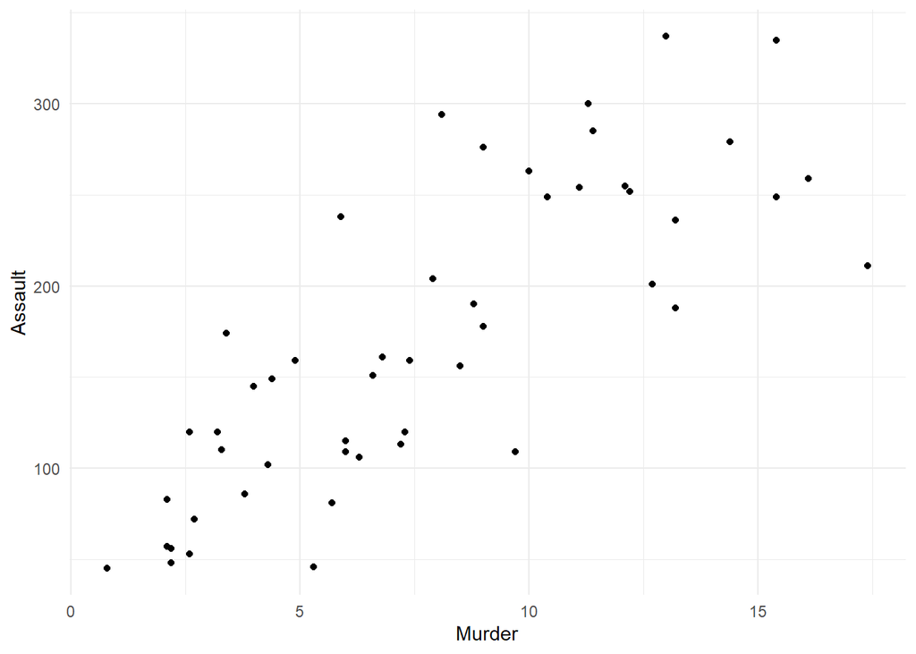

```r
df_murder_assault <- select(data, Murder, Assault)
ggplot(df_murder_assault, aes(Murder, Assault)) +
  geom_point()
```

```r
# the variables have totally different variances
summarise(df_murder_assault, across(everything(), var))
```

| Murder | Assault |
| --- | --- |
| 18.97047 | 6945.166 |

Demean the data only for easier visualizations.

```r
df_murder_assault_demeaned <- mutate(df_murder_assault, across(everything(), ~ .x - mean(.x)))
```

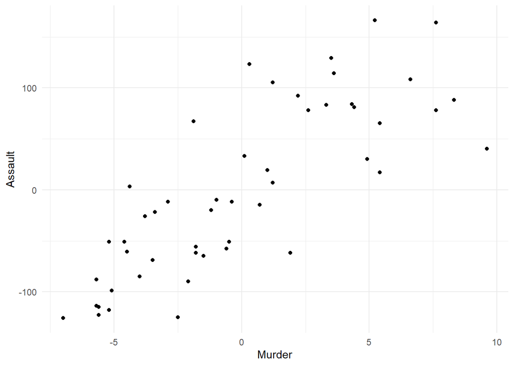

```r
ggplot(df_murder_assault_demeaned, aes(Murder, Assault)) +
  geom_point()
```

```r
# constraint: w_assault^2 + w_murder^2 = 1
# this means that w_murder = sqrt(1 - w_assault^2)

objective <- function(w_assault) {
  # we want to maximize variance
  # minus: since "optim" applies minimization.
  -var(
    w_assault * df_murder_assault_demeaned$Assault +
    sqrt(1 - w_assault^2) * df_murder_assault_demeaned$Murder
  )
}

optim_result <- optimize(f = objective, interval = c(0, 1), tol = 1e-15)
w_assault <- optim_result$minimum
w_murder <- sqrt(1 - w_assault^2)
message(glue::glue("Weight of assault: {round(w_assault, 7)} \n Weight of murder: {round(w_murder, 7)}"))
```

```
## Weight of assault: 0.9991213
## Weight of murder: 0.0419126
```

With PCA we can arrive at the same result.

```r
# Note from the help of prcomp:
# "The signs of the columns of the rotation matrix are arbitrary, and so may differ between different programs for PCA, and even between different builds of R."
pca_murder_assault <- prcomp(df_murder_assault_demeaned)
pca_murder_assault
```

```
## Standard deviations (1, .., p=2):
## [1] 83.410884  2.600107
##
## Rotation (n x k) = (2 x 2):
##                PC1        PC2
## Murder  -0.0419126  0.9991213
## Assault -0.9991213 -0.0419126
```

```r
pc1 <- pca_murder_assault$rotation[, "PC1"]
pc1
```

```
##     Murder    Assault
## -0.0419126 -0.9991213
```

Let us depict this variance-maximizing linear combination of the two variables in the space of the original variables.

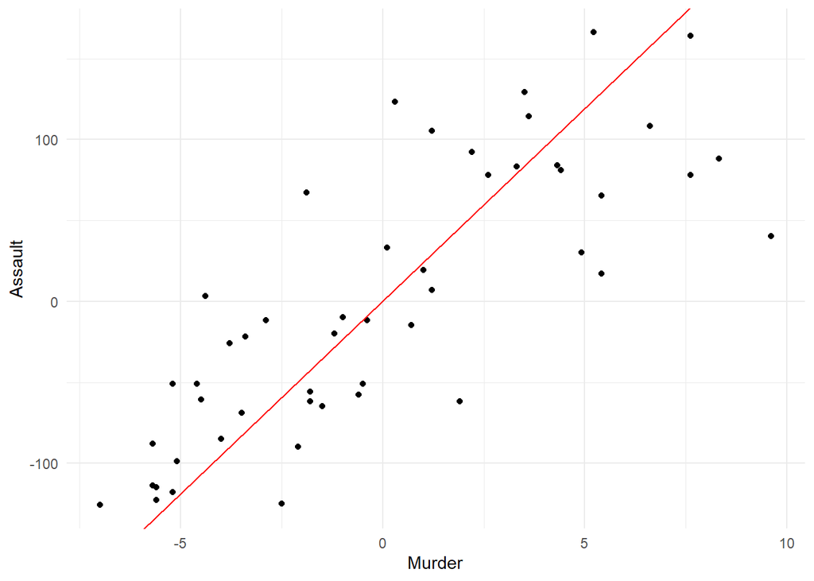

```r
ggplot(df_murder_assault_demeaned, aes(Murder, Assault)) +
  geom_point() +
  geom_abline(slope = pc1[["Assault"]] / pc1[["Murder"]], color = "red")
```

WARNING: this line is very different from regressing Assault on Murder! PCA’s aim is to find a line to which if observations are projected, variance is the highest. Regression: squared errors to be minimized.

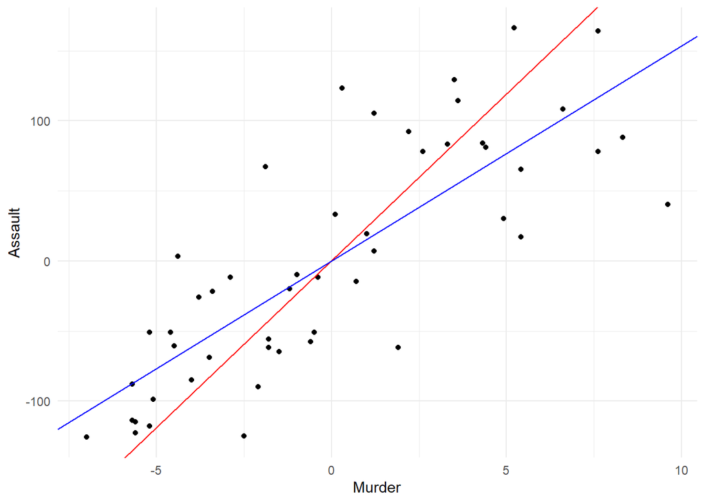

```r
ggplot(df_murder_assault_demeaned, aes(Murder, Assault)) +
  geom_point() +
  geom_abline(slope = pc1[["Assault"]] / pc1[["Murder"]], color = "red") +
  geom_abline(slope = coef(lm(Assault ~ Murder, data = df_murder_assault_demeaned))[["Murder"]], color = "blue")
```

See more about it [here](https://stats.stackexchange.com/questions/2691/making-sense-of-principal-component-analysis-eigenvectors-eigenvalues/140579#140579).

## The full example

Scaling: necessary to have comparable units of different variables. (Multiplying a variable by 100 increases the variance and PCA would try to capture that, even though it is only an artifact of units. We don’t want that.) In the previous example we did not scale all variables for the sake of nicer illustrations and we indeed saw that the variable with the higher absolute variance got a lot more weight than the other. This is not really what we are after.

Let’s perform PCA on all 4 variables. The first principal component shows weights for a linear combination of the original variables that maximizes variance (up to constraining weights to have a sum of square equal to 1).

```r
pca_result <- prcomp(data, scale. = TRUE)
print(pca_result)
```

```
## Standard deviations (1, .., p=4):
## [1] 1.5748783 0.9948694 0.5971291 0.4164494
##
## Rotation (n x k) = (4 x 4):
##                 PC1        PC2        PC3         PC4
## Murder   -0.5358995  0.4181809 -0.3412327  0.64922780
## Assault  -0.5831836  0.1879856 -0.2681484 -0.74340748
## UrbanPop -0.2781909 -0.8728062 -0.3780158  0.13387773
## Rape     -0.5434321 -0.1673186  0.8177779  0.08902432
```

```r
names(pca_result)
```

```
## [1] "sdev"     "rotation" "center"   "scale"    "x"
```

```r
# weights indeed sum to one
colSums(pca_result$rotation^2)
```

```
## PC1 PC2 PC3 PC4
##   1   1   1   1
```

```r
# PCA components are orthogonal to each other: they contain "independent" variance from the data
sum(pca_result$rotation[, 1] * pca_result$rotation[, 2])
```

```
## [1] -1.387779e-16
```

We can plot how much of total variance is captured by subsequent principal components (and in total).

```r
variances <- pca_result$sdev^2
variances
```

```
## [1] 2.4802416 0.9897652 0.3565632 0.1734301
```

Indeed, if we take the linear combination of (scaled) original variables with the weights specified by PC1, we should get back the value of the first element of `variances`.

```r
pc1_loadings <- pca_result$rotation[, "PC1"]
pc1_value_for_observations <- scale(data) %*% pc1_loadings  # %*%: matrix-vector product
var(pc1_value_for_observations)
```

```
##          [,1]
## [1,] 2.480242
```

Total variance: if scaling was done, it equals the number of variables (since it is 1 for each variable).

```r
total_variance <- sum(variances)
total_variance
```

```
## [1] 4
```

We can inspect how large share of the variance is captured by certain number of principal components.

```r
share_variance_by_component <- variances / total_variance
df_variance <- tibble(
  component = 1:length(variances),
  share_variance = share_variance_by_component
) %>%
  mutate(cum_share_variance = cumsum(share_variance))
```

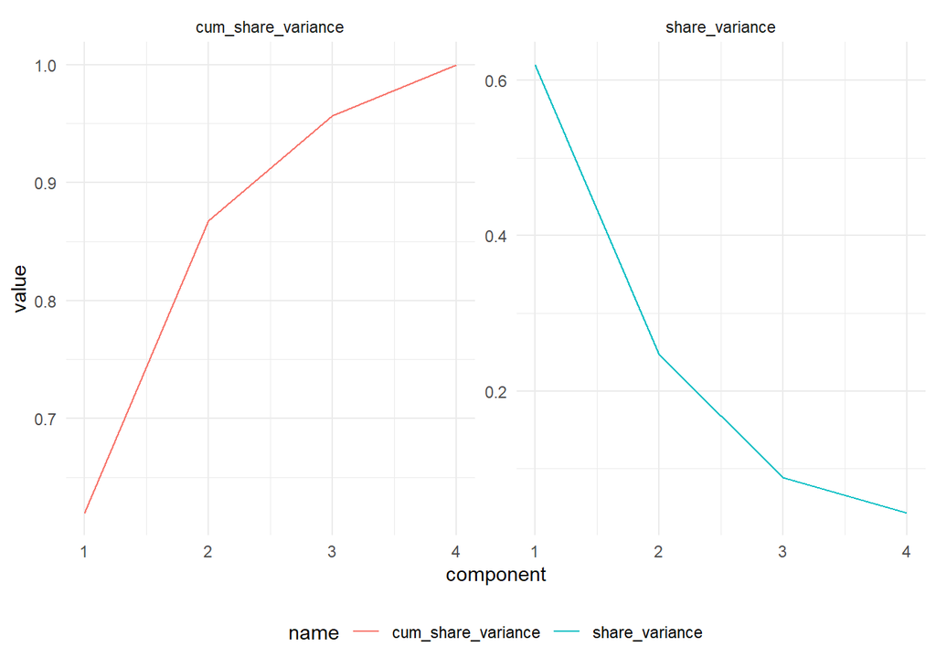

```r
ggplot(data = pivot_longer(df_variance, -component)) +
  geom_line(aes(x = component, y = value, color = name)) +
  facet_wrap(~ name, scales = "free_y") +
  theme(legend.position = "bottom")
```

How many components summarize the data? No definite answer: decide based on sufficient variance explained.

We can plot the relative contribution of original variables to principal components. They are just a visual display of the relative weights that these variables represent in creating the principal components.

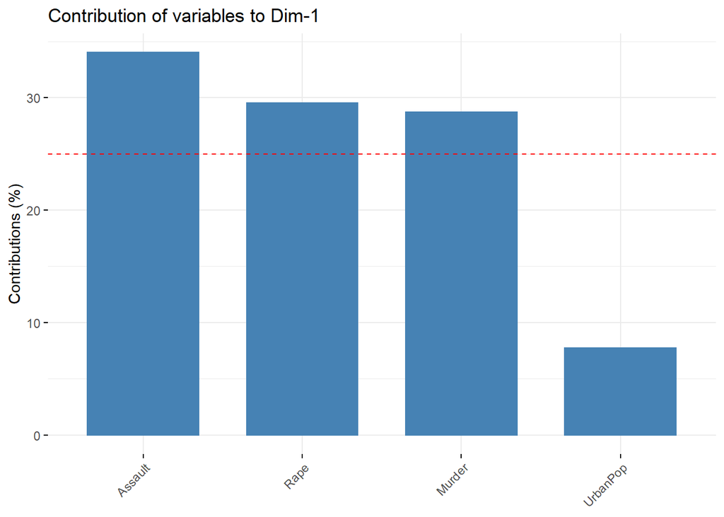

```r
fviz_contrib(pca_result, "var", axes = 1)
```

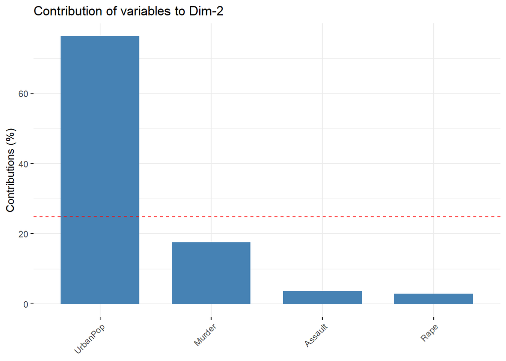

```r
fviz_contrib(pca_result, "var", axes = 2)
```

We can plot observations as well as original features in the space spanned by the first two principal components.

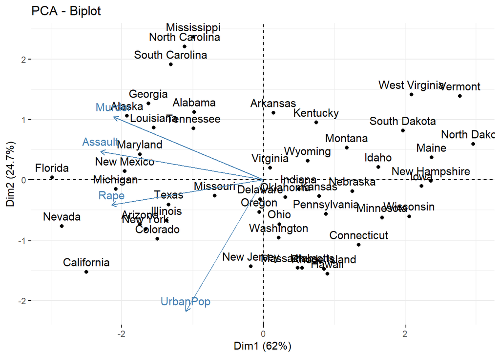

```r
fviz_pca(pca_result)
```

### PCA with `caret`

We can use `preProcess` from `caret` to perform the same transformations. These can serve as inputs to `train`.

```r
pre_process <- preProcess(data, method = c("center", "scale", "pca"))
pre_process
```

```
## Created from 50 samples and 4 variables
##
## Pre-processing:
##   - centered (4)
##   - ignored (0)
##   - principal component signal extraction (4)
##   - scaled (4)
##
## PCA needed 3 components to capture 95 percent of the variance
```

```r
pre_process$rotation
```

```
##                 PC1        PC2        PC3
## Murder   -0.5358995  0.4181809 -0.3412327
## Assault  -0.5831836  0.1879856 -0.2681484
## UrbanPop -0.2781909 -0.8728062 -0.3780158
## Rape     -0.5434321 -0.1673186  0.8177779
```

```r
pre_process <- preProcess(data, method = c("center", "scale", "pca"), pcaComp = 4)
pre_process$rotation
```

```
##                 PC1        PC2        PC3         PC4
## Murder   -0.5358995  0.4181809 -0.3412327  0.64922780
## Assault  -0.5831836  0.1879856 -0.2681484 -0.74340748
## UrbanPop -0.2781909 -0.8728062 -0.3780158  0.13387773
## Rape     -0.5434321 -0.1673186  0.8177779  0.08902432
```

```r
preProcess(data, method = c("center", "scale", "pca"), thresh = 0.6)
```

```
## Created from 50 samples and 4 variables
##
## Pre-processing:
##   - centered (4)
##   - ignored (0)
##   - principal component signal extraction (4)
##   - scaled (4)
##
## PCA needed 2 components to capture 60 percent of the variance
```

### Using PCA as an input to supervised learning

Let’s predict baseball player salaries using PCA.

```r
data <- ISLR::Hitters
print(skim(data))
```

```
## -- Data Summary ------------------------
##                            Values
## Name                       data
## Number of rows             322
## Number of columns          20
## _______________________
## Column type frequency:
##   factor                   3
##   numeric                  17
## ________________________
## Group variables            None
##
## -- Variable type: factor -------------------------------------------------------
## # A tibble: 3 x 6
##   skim_variable n_missing complete_rate ordered n_unique top_counts
## * <chr>             <int>         <dbl> <lgl>      <int> <chr>
## 1 League                0             1 FALSE          2 A: 175, N: 147
## 2 Division              0             1 FALSE          2 W: 165, E: 157
## 3 NewLeague             0             1 FALSE          2 A: 176, N: 146
##
## -- Variable type: numeric ------------------------------------------------------
## # A tibble: 17 x 11
##    skim_variable n_missing complete_rate    mean      sd    p0   p25    p50
##  * <chr>             <int>         <dbl>   <dbl>   <dbl> <dbl> <dbl>  <dbl>
##  1 AtBat                 0         1      381.    153.    16   255.   380.
##  2 Hits                  0         1      101.     46.5    1    64     96
##  3 HmRun                 0         1       10.8     8.71   0     4      8
##  4 Runs                  0         1       50.9    26.0    0    30.2   48
##  5 RBI                   0         1       48.0    26.2    0    28     44
##  6 Walks                 0         1       38.7    21.6    0    22     35
##  7 Years                 0         1        7.44    4.93   1     4      6
##  8 CAtBat                0         1     2649.   2324.    19   817.  1928
##  9 CHits                 0         1      718.    654.     4   209    508
## 10 CHmRun                0         1       69.5    86.3    0    14     37.5
## 11 CRuns                 0         1      359.    334.     1   100.   247
## 12 CRBI                  0         1      330.    333.     0    88.8  220.
## 13 CWalks                0         1      260.    267.     0    67.2  170.
## 14 PutOuts               0         1      289.    281.     0   109.   212
## 15 Assists               0         1      107.    137.     0     7     39.5
## 16 Errors                0         1        8.04    6.37   0     3      6
## 17 Salary               59         0.817  536.    451.    67.5 190    425
##       p75  p100 hist
##  *  <dbl> <dbl> <chr>
##  1  512     687 ▁▇▇▇▅
##  2  137     238 ▃▇▆▃▁
##  3   16      40 ▇▃▂▁▁
##  4   69     130 ▅▇▆▃▁
##  5   64.8   121 ▃▇▃▃▁
##  6   53     105 ▅▇▅▂▁
##  7   11      24 ▇▆▃▂▁
##  8 3924.  14053 ▇▃▂▁▁
##  9 1059.   4256 ▇▃▁▁▁
## 10   90     548 ▇▁▁▁▁
## 11  526.   2165 ▇▂▁▁▁
## 12  426.   1659 ▇▂▁▁▁
## 13  339.   1566 ▇▂▁▁▁
## 14  325    1378 ▇▃▁▁▁
## 15  166     492 ▇▂▁▁▁
## 16   11      32 ▇▅▂▁▁
## 17  750    2460 ▇▃▁▁▁
```

```r
data <- drop_na(data, Salary)
```

Train a simple linear model:

```r
set.seed(857)
lm_fit <- train(
  Salary ~ . ,
  data = data,
  method = "lm",
  trControl = trainControl(method = "cv", number = 10),
  preProcess = c("center", "scale")
)
lm_fit
```

```
## Linear Regression
##
## 263 samples
##  19 predictor
##
## Pre-processing: centered (19), scaled (19)
## Resampling: Cross-Validated (10 fold)
## Summary of sample sizes: 238, 238, 236, 237, 236, 236, ...
## Resampling results:
##
##   RMSE      Rsquared   MAE
##   339.9014  0.4934518  239.8877
##
## Tuning parameter 'intercept' was held constant at a value of TRUE
```

We can use PCA with specified number of components (or we can also set the `thresh` argument to set a threshold that PCA components explain at least a certain share of the variance):

```r
set.seed(857)
lm_fit_pca <- train(
  Salary ~ . ,
  data = data,
  method = "lm",
  trControl = trainControl(
    method = "cv",
    number = 10,
    preProcOptions = list(pcaComp = 18)),
  preProcess = c("center", "scale", "pca")
)
lm_fit_pca
```

```
## Linear Regression
##
## 263 samples
##  19 predictor
##
## Pre-processing: centered (19), scaled (19), principal component
##  signal extraction (19)
## Resampling: Cross-Validated (10 fold)
## Summary of sample sizes: 238, 238, 236, 237, 236, 236, ...
## Resampling results:
##
##   RMSE      Rsquared   MAE
##   335.5006  0.5033328  236.9515
##
## Tuning parameter 'intercept' was held constant at a value of TRUE
```

```r
lm_fit_pca$preProcess
```

```
## Created from 263 samples and 19 variables
##
## Pre-processing:
##   - centered (19)
##   - ignored (0)
##   - principal component signal extraction (19)
##   - scaled (19)
##
## PCA used 18 components as specified
```

Method `pcr` implements precisely this: linear regression with principal components as explanatory variables. Its hyperparameter is the number of components to be used.

```r
tune_grid <- data.frame(ncomp = 1:19)
set.seed(857)
pcr_fit <- train(
  Salary ~ . ,
  data = data,
  method = "pcr",
  trControl = trainControl(method = "cv", number = 10),
  tuneGrid = tune_grid,
  preProcess = c("center", "scale")
)
pcr_fit
```

```
## Principal Component Analysis
##
## 263 samples
##  19 predictor
##
## Pre-processing: centered (19), scaled (19)
## Resampling: Cross-Validated (10 fold)
## Summary of sample sizes: 238, 238, 236, 237, 236, 236, ...
## Resampling results across tuning parameters:
##
##   ncomp  RMSE      Rsquared   MAE
##    1     348.5858  0.4551672  235.8581
##    2     346.8850  0.4537499  233.9847
##    3     347.4421  0.4515505  232.9970
##    4     345.3761  0.4560361  232.8832
##    5     341.3418  0.4634937  234.9266
##    6     337.5116  0.4760701  230.1170
##    7     338.5258  0.4756865  230.5910
##    8     340.6917  0.4705917  232.0863
##    9     342.4566  0.4665562  233.6436
##   10     343.1646  0.4645628  234.9598
##   11     344.0339  0.4614884  236.2881
##   12     345.5128  0.4580380  237.4320
##   13     347.1870  0.4571486  240.8661
##   14     344.2335  0.4672140  244.3308
##   15     346.7001  0.4571525  246.2643
##   16     335.4976  0.4930390  238.3030
##   17     334.8186  0.5014230  235.7825
##   18     335.5006  0.5033328  236.9515
##   19     339.9014  0.4934518  239.8877
##
## RMSE was used to select the optimal model using the smallest value.
## The final value used for the model was ncomp = 17.
```

## K-means clustering

Goal: group observations that are more similar to each other than to others.

```r
data <- clean_names(iris)
print(skim(data))
```

```
## -- Data Summary ------------------------
##                            Values
## Name                       data
## Number of rows             150
## Number of columns          5
## _______________________
## Column type frequency:
##   factor                   1
##   numeric                  4
## ________________________
## Group variables            None
##
## -- Variable type: factor -------------------------------------------------------
## # A tibble: 1 x 6
##   skim_variable n_missing complete_rate ordered n_unique
## * <chr>             <int>         <dbl> <lgl>      <int>
## 1 species               0             1 FALSE          3
##   top_counts
## * <chr>
## 1 set: 50, ver: 50, vir: 50
##
## -- Variable type: numeric ------------------------------------------------------
## # A tibble: 4 x 11
##   skim_variable n_missing complete_rate  mean    sd    p0   p25   p50   p75
## * <chr>             <int>         <dbl> <dbl> <dbl> <dbl> <dbl> <dbl> <dbl>
## 1 sepal_length          0             1  5.84 0.828   4.3   5.1  5.8    6.4
## 2 sepal_width           0             1  3.06 0.436   2     2.8  3      3.3
## 3 petal_length          0             1  3.76 1.77    1     1.6  4.35   5.1
## 4 petal_width           0             1  1.20 0.762   0.1   0.3  1.3    1.8
##    p100 hist
## * <dbl> <chr>
## 1   7.9 ▆▇▇▅▂
## 2   4.4 ▁▆▇▂▁
## 3   6.9 ▇▁▆▇▂
## 4   2.5 ▇▁▇▅▃
```

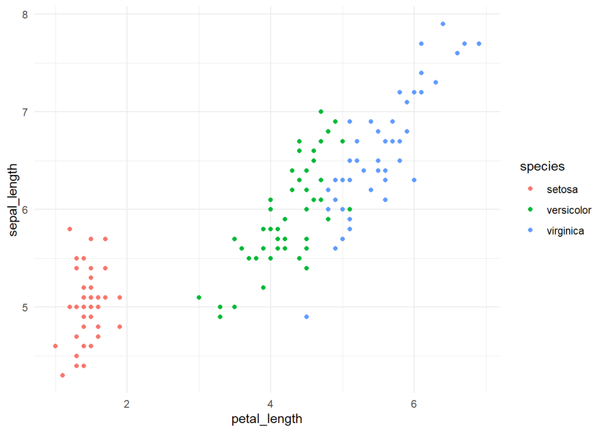

```r
ggplot(data, aes(x = petal_length, y = sepal_length, color = species)) + geom_point()
```

Suppose we do not know labels but want to group observations based on features.

```r
data_features <- select(data, -species)
km <- kmeans(data_features, centers = 3)
km
```

```
## K-means clustering with 3 clusters of sizes 38, 50, 62
##
## Cluster means:
##   sepal_length sepal_width petal_length petal_width
## 1     6.850000    3.073684     5.742105    2.071053
## 2     5.006000    3.428000     1.462000    0.246000
## 3     5.901613    2.748387     4.393548    1.433871
##
## Clustering vector:
##   [1] 2 2 2 2 2 2 2 2 2 2 2 2 2 2 2 2 2 2 2 2 2 2 2 2 2 2 2 2 2 2 2 2 2 2 2 2 2
##  [38] 2 2 2 2 2 2 2 2 2 2 2 2 2 3 3 1 3 3 3 3 3 3 3 3 3 3 3 3 3 3 3 3 3 3 3 3 3
##  [75] 3 3 3 1 3 3 3 3 3 3 3 3 3 3 3 3 3 3 3 3 3 3 3 3 3 3 1 3 1 1 1 1 3 1 1 1 1
## [112] 1 1 3 3 1 1 1 1 3 1 3 1 3 1 1 3 3 1 1 1 1 1 3 1 1 1 1 3 1 1 1 3 1 1 1 3 1
## [149] 1 3
##
## Within cluster sum of squares by cluster:
## [1] 23.87947 15.15100 39.82097
##  (between_SS / total_SS =  88.4 %)
##
## Available components:
##
## [1] "cluster"      "centers"      "totss"        "withinss"     "tot.withinss"
## [6] "betweenss"    "size"         "iter"         "ifault"
```

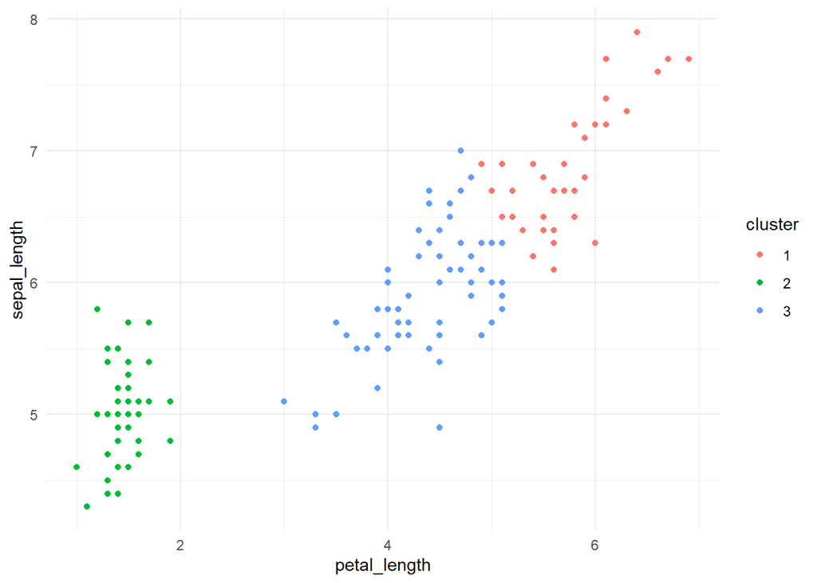

```r
data_w_clusters <- mutate(data_features, cluster = factor(km$cluster))

ggplot(data_w_clusters, aes(x = petal_length, y = sepal_length, color = cluster)) +
  geom_point()
```

We can inspect the resulting centers.

```r
km$centers
```

```
##   sepal_length sepal_width petal_length petal_width
## 1     6.850000    3.073684     5.742105    2.071053
## 2     5.006000    3.428000     1.462000    0.246000
## 3     5.901613    2.748387     4.393548    1.433871
```

```r
centers <- as_tibble(km$centers) %>%
  mutate(cluster = factor(seq(nrow(km$centers))), center = TRUE)
kable(centers, digits = 3) %>%
  kable_styling(full_width = F)
```

| sepal_length | sepal_width | petal_length | petal_width | cluster | center |
| --- | --- | --- | --- | --- | --- |
| 6.850 | 3.074 | 5.742 | 2.071 | 1 | TRUE |
| 5.006 | 3.428 | 1.462 | 0.246 | 2 | TRUE |
| 5.902 | 2.748 | 4.394 | 1.434 | 3 | TRUE |

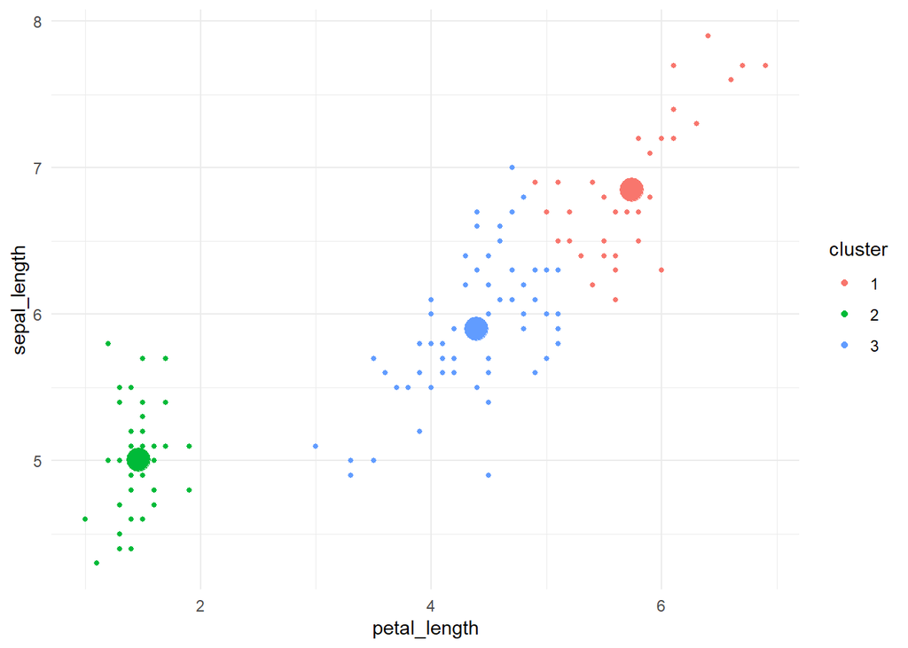

```r
plot_clusters_with_centers <- function(features, kmeans_object) {

  data_w_clusters <- mutate(features, cluster = factor(kmeans_object$cluster))

  centers <- as_tibble(kmeans_object$centers) %>%
    mutate(cluster = factor(seq(nrow(km$centers))), center = TRUE)

  data_w_clusters_centers <- bind_rows(data_w_clusters, centers)
  ggplot(data_w_clusters_centers, aes(
    x = petal_length, y = sepal_length,
    color = cluster, size = ifelse(!is.na(center), 2, 1))
  ) +
    geom_point() +
    scale_size(guide = 'none')
}

plot_clusters_with_centers(data_features, km)
```

Results depend on the starting centers which are randomly chosen observations.

```r
set.seed(1122)
km <- kmeans(data_features, centers = 3, nstart = 1)
print(km$centers)
```

```
##   sepal_length sepal_width petal_length petal_width
## 1     6.850000    3.073684     5.742105    2.071053
## 2     5.901613    2.748387     4.393548    1.433871
## 3     5.006000    3.428000     1.462000    0.246000
```

```r
print(table(km$cluster))
```

```
##
##  1  2  3
## 38 62 50
```

```r
print(km$withinss)
```

```
## [1] 23.87947 39.82097 15.15100
```

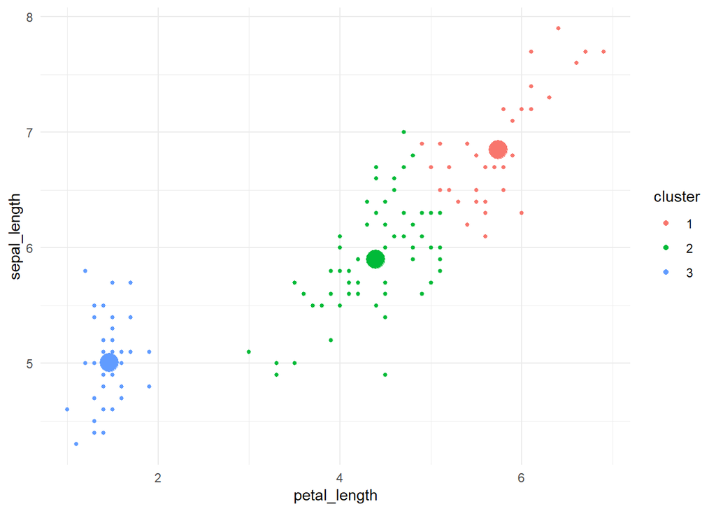

```r
plot_clusters_with_centers(data_features, km)
```

```r
set.seed(223456)
km <- kmeans(data_features, centers = 7, nstart = 40)
print(km$centers)
```

```
##   sepal_length sepal_width petal_length petal_width
## 1     6.568182    3.086364     5.536364   2.1636364
## 2     6.036842    2.705263     5.000000   1.7789474
## 3     7.475000    3.125000     6.300000   2.0500000
## 4     4.704545    3.122727     1.413636   0.2000000
## 5     6.442105    2.978947     4.594737   1.4315789
## 6     5.242857    3.667857     1.500000   0.2821429
## 7     5.532143    2.635714     3.960714   1.2285714
```

```r
print(table(km$cluster))
```

```
##
##  1  2  3  4  5  6  7
## 22 19 12 22 19 28 28
```

```r
print(km$withinss)
```

```
## [1] 4.315455 4.125263 4.655000 3.114091 3.708421 4.630714 9.749286
```

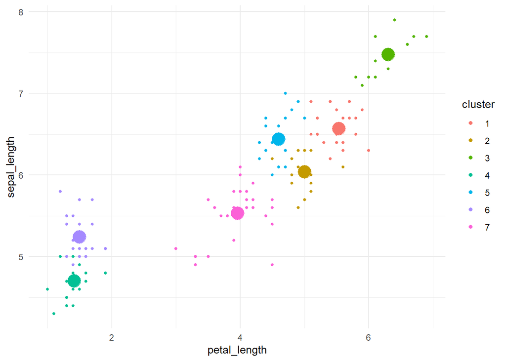

```r
plot_clusters_with_centers(data_features, km)
```

```r
km
```

```
## K-means clustering with 7 clusters of sizes 22, 19, 12, 22, 19, 28, 28
##
## Cluster means:
##   sepal_length sepal_width petal_length petal_width
## 1     6.568182    3.086364     5.536364   2.1636364
## 2     6.036842    2.705263     5.000000   1.7789474
## 3     7.475000    3.125000     6.300000   2.0500000
## 4     4.704545    3.122727     1.413636   0.2000000
## 5     6.442105    2.978947     4.594737   1.4315789
## 6     5.242857    3.667857     1.500000   0.2821429
## 7     5.532143    2.635714     3.960714   1.2285714
##
## Clustering vector:
##   [1] 6 4 4 4 6 6 4 6 4 4 6 4 4 4 6 6 6 6 6 6 6 6 4 6 4 4 6 6 6 4 4 6 6 6 4 4 6
##  [38] 6 4 6 6 4 4 6 6 4 6 4 6 4 5 5 5 7 5 7 5 7 5 7 7 7 7 5 7 5 7 7 2 7 2 7 2 5
##  [75] 5 5 5 5 5 7 7 7 7 2 7 5 5 5 7 7 7 5 7 7 7 7 7 5 7 7 1 2 3 1 1 3 7 3 1 3 1
## [112] 2 1 2 2 1 1 3 3 2 1 2 3 2 1 3 2 2 1 3 3 3 1 2 2 3 1 1 2 1 1 1 2 1 1 1 2 1
## [149] 1 2
##
## Within cluster sum of squares by cluster:
## [1] 4.315455 4.125263 4.655000 3.114091 3.708421 4.630714 9.749286
##  (between_SS / total_SS =  95.0 %)
##
## Available components:
##
## [1] "cluster"      "centers"      "totss"        "withinss"     "tot.withinss"
## [6] "betweenss"    "size"         "iter"         "ifault"
```

We should always experiment with different starting values (probably generated randomly). `nstart` controls how many times the algorithm is run with different random starting points for the centers. Setting it to a high value (e.g., 20) is a good idea to achieve the best groupings.

### Choosing K

There are no general rules, depends on the application. There are some rules of thumb, though. There are many, you can explore some with explanation, [here](http://www.sthda.com/english/wiki/print.php?id=239).

A popular one looks at the evolution of the within-sum-of-squares, and identifies the “elbow” point for the optimal number of clusters

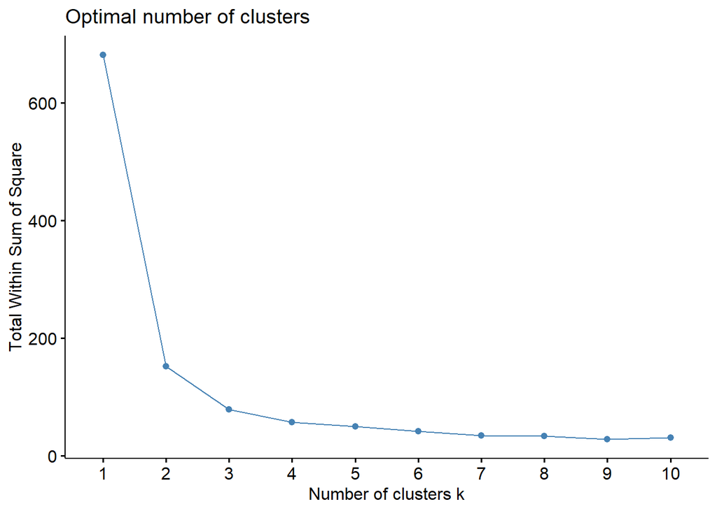

```r
fviz_nbclust(data_features, kmeans, method = "wss")
```

`NbClust` calculates 30 indices based on various principles and chooses by majority rule.

```r
nb <- NbClust(data_features, method = "kmeans", min.nc = 2, max.nc = 10, index = "all")
```

[figure not shown]

[figure not shown]

```r
nb
```

[output not shown]

## Hierarchical clustering

With hierarchical clustering we get a nested structure of clusters based on a dissimilarity measure. Is it better than k-means? It depends - k-means does not yield a hierarchical structure. If the data does not have one in reality, hierarchical may be not as good as k-means and there are reversed situations as well.

```r
data_distances <- dist(data_features)
# use the average distance between groups to decide which
# groups to merge next
hc <- hclust(data_distances, method = "average")
```

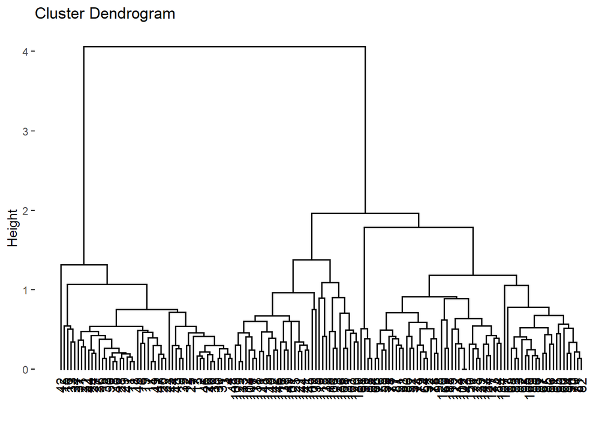

```r
fviz_dend(hc)
```

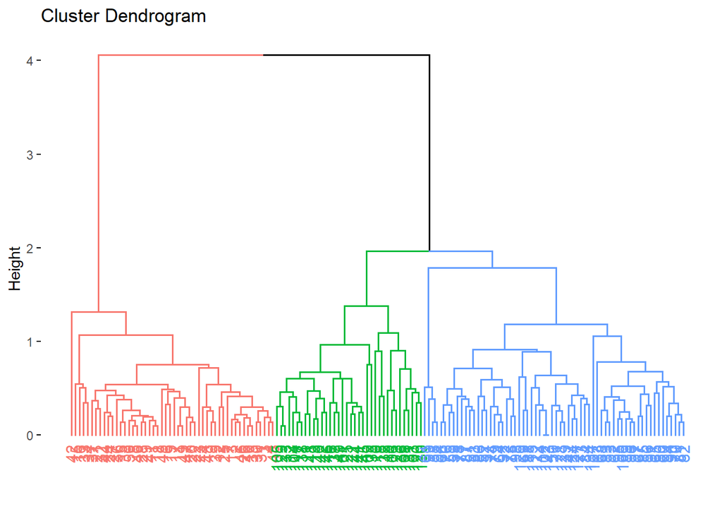

```r
fviz_dend(hc, k = 3)
```

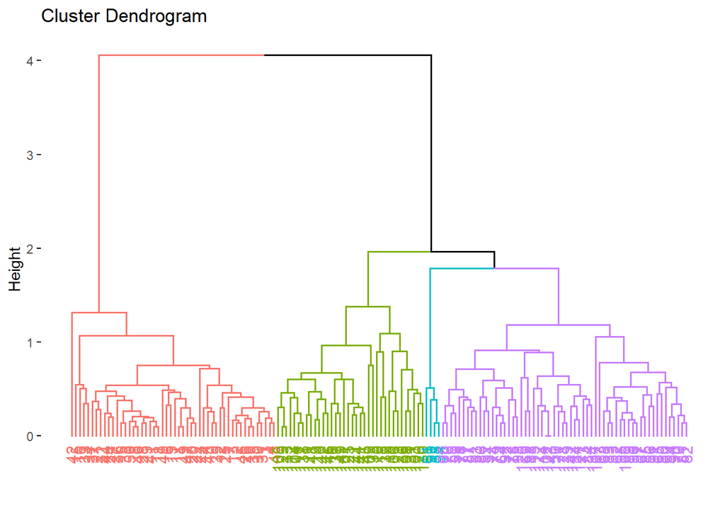

```r
fviz_dend(hc, k = 4)
```

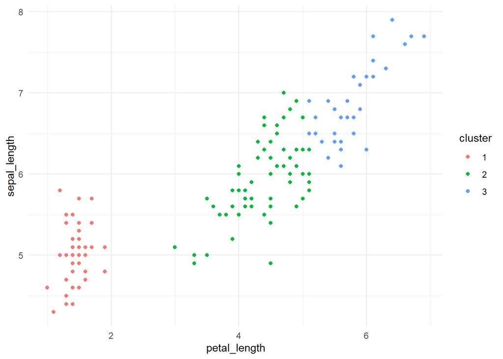

```r
# get labels
cluster_hc <- cutree(hc, 3)
data_w_clusters <- mutate(data_features, cluster = factor(cluster_hc))

ggplot(data_w_clusters, aes(x = petal_length, y = sepal_length, color = cluster)) +
  geom_point()
```

How we calculate similarities between groups may strongly affect the clustering.

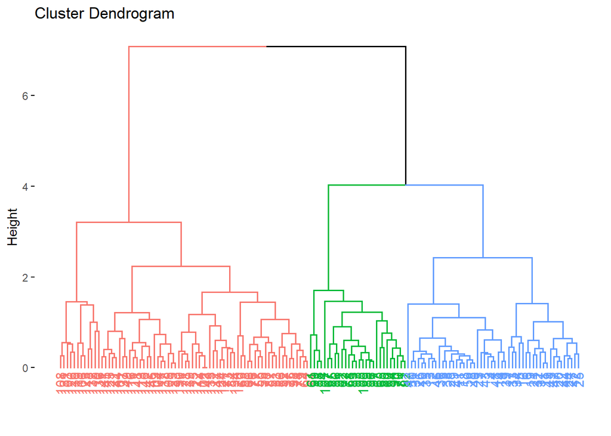

```r
# max distance between points of two groups
hc_complete <- hclust(data_distances, method = "complete")
fviz_dend(hc_complete, k = 3)
```

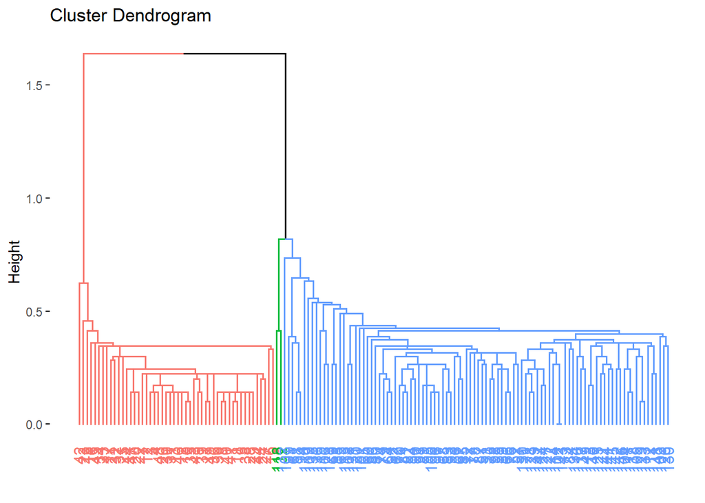

```r
# single: minimal distance between points of two groups
hc_single <- hclust(data_distances, method = "single")
fviz_dend(hc_single, k = 3)
```

## General considerations on clustering

- as both clustering methods are based on distances in features, we may want to first bring all variables to the same scale
- clusters may be sensitive to details such as scaling or not, whether we take subsets of data or what is the dissimilarity measure in hierarchical clustering. Advice: experiment with the settings and look for consistent patterns.